# Data Description

Reference: https://www.kaggle.com/c/web-traffic-time-series-forecasting/data

```
Original data: train_1.csv
-----------------------------
rows = 145,063
columns = 551
first column = Page
date columns = 2015-07-01, 2015-07-02, ..., 2016-12-31 (550 columns)
file size: 284.6 MB


Data for time series
----------------------------------------------
selected year: 2016 (leap year 366 days)

selected time series:

The most visited page.
df['Page'] == """Special:Search_en.wikipedia.org_desktop_all-agents"""
```

# Load the libraries

```python
import numpy as np
import pandas as pd
import seaborn as sns
sns.set(color_codes=True)

import matplotlib
import matplotlib.pyplot as plt
%matplotlib inline
%config InlineBackend.figure_format = 'retina'
sns.set(context='notebook', style='whitegrid', rc={'figure.figsize': (12,8)})
plt.style.use('fivethirtyeight') # better than sns styles.
matplotlib.rcParams['figure.figsize'] = 12,8

import os
import time

# random state
random_state=100
np.random.seed(random_state)

# Jupyter notebook settings for pandas
#pd.set_option('display.float_format', '{:,.2g}'.format) # numbers sep by comma
from pandas.api.types import CategoricalDtype
np.set_printoptions(precision=3)
pd.set_option('display.max_columns', 100)
pd.set_option('display.max_rows', 100) # None for all the rows
pd.set_option('display.max_colwidth', 200)

import IPython
from IPython.display import display, HTML, Image, Markdown


import gc

import scipy
from scipy import stats
from scipy.stats import shapiro # Shapiro-Wilk normality
from statsmodels.tsa.stattools import adfuller # Augmented Dickey-Fuller stationarity

import statsmodels
import statsmodels.api as sm
import statsmodels.formula.api as smf
import statsmodels.graphics.api as smg
import statsmodels.robust as smrb # smrb.mad() etc
import patsy # y,X1 = patsy.dmatrices(formula, df, return_type='dataframe')

from statsmodels.tsa.stattools import acf
from statsmodels.tsa.stattools import pacf

from statsmodels.graphics.tsaplots import plot_acf, plot_pacf
from statsmodels.tsa.seasonal import seasonal_decompose # sm.tsa.seasonal_decompose

from pandas.plotting import autocorrelation_plot
from pandas.plotting import lag_plot

# versions
import watermark
%load_ext watermark
%watermark -a "Bhishan Poudel" -d -v -m
print()
%watermark -iv
```

```
Bhishan Poudel 2020-10-14

CPython 3.7.7
IPython 7.18.1

compiler   : Clang 4.0.1 (tags/RELEASE_401/final)
system     : Darwin
release    : 19.6.0
machine    : x86_64
processor  : i386
CPU cores  : 4
interpreter: 64bit

scipy           1.4.1
autopep8        1.5.2
statsmodels.api 0.12.0
pandas          1.1.0
numpy           1.18.4
json            2.0.9
matplotlib      3.2.1
watermark       2.0.2
seaborn         0.11.0
IPython         7.18.1
patsy           0.5.1
```

```python
%%javascript
IPython.OutputArea.auto_scroll_threshold = 9999;
```

# Useful Functions

```python
def show_methods(obj, ncols=4):
    lst = [i for i in dir(obj) if i[0]!='_' ]
    df = pd.DataFrame(np.array_split(lst,ncols)).T.fillna('')
    return df
```

# Load the data

```python
df = pd.read_csv('../data/train_1.csv.zip',compression='zip',encoding='latin-1')

cond = df['Page'] == """Special:Search_en.wikipedia.org_desktop_all-agents"""
df = df.loc[cond]
df = df.filter(regex="Page|2016")
df = df.melt(id_vars=['Page'],var_name='date',value_name='visits').drop('Page',axis=1)
df = df.dropna(how='any')

print(df.shape)
df.iloc[:2,:5]
```

```
(366, 2)
```

|  | date | visits |
| --- | --- | --- |
| 0 | 2016-01-01 | 1401667.0 |
| 1 | 2016-01-02 | 1395136.0 |

# Timeseries Statistics

```python
df['date'] = pd.to_datetime(df['date'])
ts = df[['visits','date']].set_index('date')

ts.head()
```

| date | visits |
| --- | --- |
| 2016-01-01 | 1401667.0 |
| 2016-01-02 | 1395136.0 |
| 2016-01-03 | 1455522.0 |
| 2016-01-04 | 1750373.0 |
| 2016-01-05 | 1787494.0 |

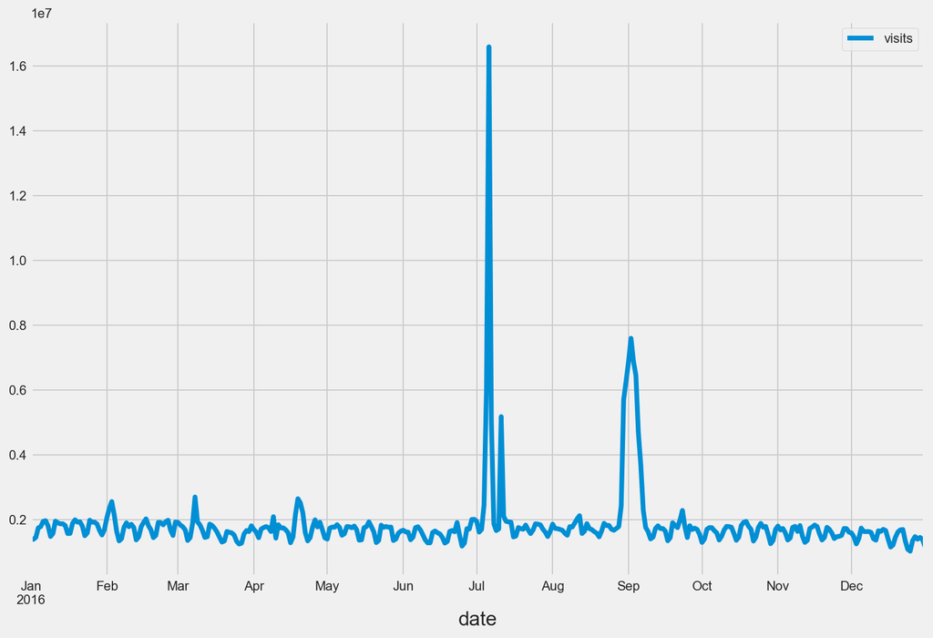

```python
ts.plot()

# ts is periodic
# ts has some very large peaks
# ts in not going upward, it does not have trend (it may have if I have more years)
```

```python
# Monthly subplots
```

```python
#ts.groupby(ts.index.month).plot()
```

```python
ts.asfreq('MS')
```

| date | visits |
| --- | --- |
| 2016-01-01 | 1401667.0 |
| 2016-02-01 | 2058777.0 |
| 2016-03-01 | 1920594.0 |
| 2016-04-01 | 1700498.0 |
| 2016-05-01 | 1402524.0 |
| 2016-06-01 | 1678428.0 |
| 2016-07-01 | 1954525.0 |
| 2016-08-01 | 1864873.0 |
| 2016-09-01 | 6878515.0 |
| 2016-10-01 | 1299740.0 |
| 2016-11-01 | 1806303.0 |
| 2016-12-01 | 1594861.0 |

# Normality Test

Reference: https://machinelearningmastery.com/a-gentle-introduction-to-normality-tests-in-python/

- Histogram plot
- QQ plot
- Shapiro-Wilk Test (H0: IS normal)
- D’Agostino’s K^2 Test (H0: data IS normal based on skewness and kurtosis)
- Anderson-Darling Test

```
import statsmodels.api as sm
from scipy import stats
x = stats.norm.rvs(loc=5, scale=3, size=1000) # mean=5, std=3

# qq-plot
sm.qqplot(x, loc = 5, scale = 3, line='s')

# shapiro-wilk
res = stats.shapiro(x)

# anderson-darling
res = stats.anderson(x, dist='norm')
```

```python
from scipy.stats import shapiro
def shapiro_normality_test(ts, sig=0.05):
    """
    Shapiro-Wilk test of normality


    H0: data IS normally distributed
    H1: data is NOT normally distributed.

    if p < 0.05, we reject the null hypothesis and say data is NOT normal.

    Example:
    from scipy import stats
    x_1000 = stats.norm.rvs(loc=5, scale=3, size=1000)
    shapiro_normality_test(x_1000)

    Example:
    ts = pandas series with datetime index and some values
    ts = ts.to_numpy().ravel() # make it numpy array
    shapiro_normality_test(ts.to_numpy().ravel())

    NOTE:
    In linear regression, the residuals must follow normal distribution.
    """

    p_value = shapiro(ts)[1]
    mu = np.round(np.mean(ts),3)
    sigma = np.round(np.std(ts),3)

    if p_value < sig:
        print("Reject H0: that data follows normal distribution.")
        print("**Data is NOT normally distributed.**")
        print("Shapiro-Wilk p_value={}".format(np.round(p_value,3)))
    else:
        print("Accept H0: that data follows normal distribution.")
        print("**Data IS normally distributed.**")
        print("Shapiro-Wilk p_value={}".format(np.round(p_value,3)))

shapiro_normality_test(ts.to_numpy().ravel())
```

```
Reject H0: that data follows normal distribution.
**Data is NOT normally distributed.**
Shapiro-Wilk p_value=0.0
```

# Stationarity Test (Augmented Dickey Fuller Test)

Ref: https://www.analyticsvidhya.com/blog/2018/09/non-stationary-time-series-python/

# ------------------------------------------------------------------------------

**Stationarity Tests**

Unit root indicates that the statistical properties of a given series are not constant with time, which is the condition for stationary time series.

Suppose we have a time series :

yt = a*yt-1 + ε t

where yt is the value at the time instant t and ε t is the error term. In order to calculate yt we need the value of yt-1, which is :

yt-1 = a*yt-2 + ε t-1

If we do that for all observations, the value of yt will come out to be:

yt = an*yt-n + Σεt-i*ai

If the value of a is 1 (unit) in the above equation, then the predictions will be equal to the yt-n and sum of all errors from t-n to t, which means that the variance will increase with time.

This is knows as unit root in a time series. We know that for a stationary time series, the variance must not be a function of time.

The unit root tests check the presence of unit root in the series by checking if value of a=1.

The two most popular test of unit root are:

- ADF (Augmented Dickey Fuller) Test (H0: test is NOT stationary)
- KPSS (Kwiatkowski-Phillips-Schmidt-Shin) Test (H0: test IS stationary)

# ------------------------------------------------------------------------------

**Types of Stationarity**  
Let us understand the different types of stationarities and how to interpret the results of the above tests.

- Strict Stationary: A strict stationary series satisfies the mathematical definition of a stationary process. For a strict stationary series, the mean, variance and covariance are not the function of time. The aim is to convert a non-stationary series into a strict stationary series for making predictions.
- Trend Stationary: A series that has no unit root but exhibits a trend is referred to as a trend stationary series. Once the trend is removed, the resulting series will be strict stationary. The KPSS test classifies a series as stationary on the absence of unit root. This means that the series can be strict stationary or trend stationary.
- Difference Stationary: A time series that can be made strict stationary by differencing falls under difference stationary. ADF test is also known as a difference stationarity test.

It’s always better to apply both the tests, so that we are sure that the series is truly stationary. Let us look at the possible outcomes of applying these stationary tests.

- Case 1: Both tests conclude that the series is not stationary -> series is not stationary
- Case 2: Both tests conclude that the series is stationary -> series is stationary
- Case 3: KPSS = stationary and ADF = not stationary -> trend stationary, remove the trend to make series strict stationary
- Case 4: KPSS = not stationary and ADF = stationary -> difference stationary, use differencing to make series stationary

# ------------------------------------------------------------------------------

**Making a Time Series Stationary**

- differencing: yt‘ = yt – y(t-1) # ts - ts.shift(1)
- Seasonal Differencing: yt‘ = yt – y(t-n) # n=7 for weekly variation
- transformation: ts_log and ts_log_diff

```python
from statsmodels.tsa.stattools import adfuller

def stationarity_test_adfuller(ts,sig=0.05):
    """
    Augmented Dickey Fuller Test

    H0: There is a unit root in the time series sample. (no stationary)
    H1: Data IS stationary.

    The augmented Dickey–Fuller (ADF) statistic,
    used in the test, is a negative number.

    The more negative it is, the stronger the rejection of the hypothesis
    that there is a unit root at some level of confidence.

    If p < 0.05, we reject the null hypothesis and say data is stationary.

    Usage:
    ts = ts.to_numpy().ravel()
    stationarity_test_adfuller(ts)

    """

    statistic = adfuller(ts)[0]
    p_val=adfuller(ts)[1]

    if p_val < sig:
        print("Reject H0: that the time series have a unit root and is not stationary.")
        print("**Data IS stationary.**")
        print("Augmented Dickey-Fuller p_value={}".format(np.round(p_val,3)))
        print("Augmented Dickey-Fuller statistic{}".format(np.round(statistic,3)))
    else:
        print("Accept H0: that time series have a unit root and is not stationary.")
        print("**Data is NOT stationary.**")
        print("Augmented Dickey-Fuller p_value={}".format(np.round(p_val,3)))
        print("Augmented Dickey-Fuller statistic={}".format(np.round(statistic,3)))

stationarity_test_adfuller(ts.to_numpy().ravel())
```

```
Reject H0: that the time series have a unit root and is not stationary.
**Data IS stationary.**
Augmented Dickey-Fuller p_value=0.0
Augmented Dickey-Fuller statistic-6.02
```

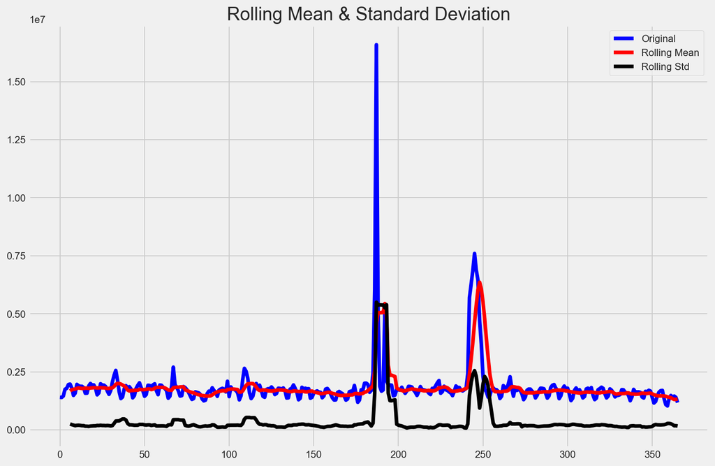

```
ADF Statistic: -6.020090
p-value: 0.000000
**Timeseries IS stationary**
```

```python
def test_stationarity(ts,window=7):
    # rolling statistics
    rolmean = ts.rolling(window=window, center=False).mean()
    rolstd = ts.rolling(window=window, center=False).std()

    x = ts.to_numpy().ravel()

    # Plot rolling statistics
    plt.figure(figsize=(12,8))
    orig = plt.plot(x, color='blue', label='Original')
    mean = plt.plot(rolmean.values, color='red', label='Rolling Mean')
    std = plt.plot(rolstd.values, color='black', label='Rolling Std')
    plt.legend(loc='best')
    plt.title('Rolling Mean & Standard Deviation')
    plt.show(block=False)

    # Augmented Dickey-Fuller test
    result = adfuller(x)
    print(F"ADF Statistic: {result[0]:f}")
    print(F"p-value: {result[1]:f}")
    pvalue=result[1]
    for key, value in result[4].items():
        if result[0] > value:
            print("**Timeseries is NOT stationary**")
            break
        else:
            print('**Timeseries IS stationary**')
            break


test_stationarity(ts)
```

# Auto correlation plots

```python
import statsmodels.graphics.tsaplots
show_methods(statsmodels.graphics.tsaplots,8)
```

|  | 0 | 1 | 2 | 3 | 4 | 5 | 6 | 7 |
| --- | --- | --- | --- | --- | --- | --- | --- | --- |
| 0 | acf | month_plot | pacf | plot_acf | plot_predict | quarter_plot | seasonal_plot | utils |
| 1 | deprecate_kwarg | np | pd | plot_pacf |  |  |  |  |

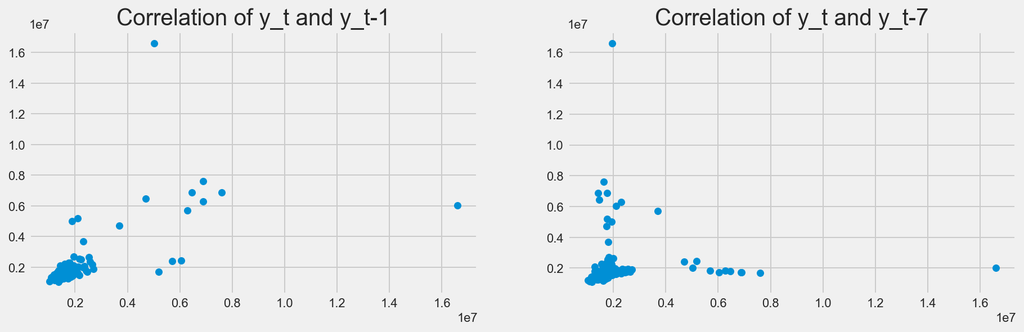

```python
def simple_autocorrelation_plot(ts):
    fig, axes = plt.subplots(1,2, squeeze=False);
    fig.set_size_inches(14,4);
    axes[0,0].scatter(x=ts[1:], y=ts.shift(1)[1:]);
    axes[0,1].scatter(x=ts[7:], y=ts.shift(7)[7:]);
    axes[0,0].set_title('Correlation of y_t and y_t-1');
    axes[0,1].set_title('Correlation of y_t and y_t-7');

simple_autocorrelation_plot(ts)
```

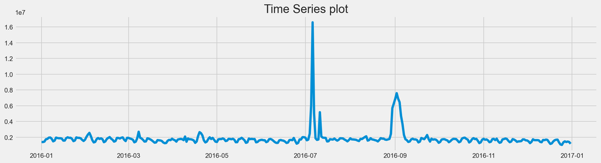

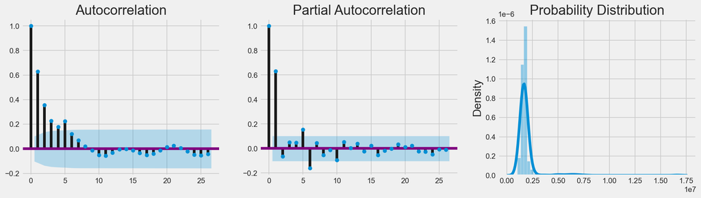

```python
def plot_correlations(ts, title="Time Series plot",
                      xlabel='',ylabel='',lags=None):
    """Correlation plots
    Row1: lineplot of time series
    Row2: correlation plot, partial-corr plot (mulitivariate), density plot

    References: https://github.com/statsmodels/statsmodels/blob/master/examples/notebooks/regression_plots.ipynb
    """
    from statsmodels.graphics.tsaplots import plot_acf, plot_pacf

    # first row plot:
    # time series plot
    plt.figure(figsize=(16,4))
    plt.plot(ts)
    plt.title(title)
    plt.ylabel(ylabel)
    plt.xlabel(xlabel)

    # second row plots:
    fig, axes = plt.subplots(1,3,squeeze=False)
    fig.set_size_inches(16,4)

    # acf auto correlation function
    plot_acf(ts, ax=axes[0,0], lags=lags);

    # pacf (partial auto correlation function for multi-variate regression)
    plot_pacf(ts, ax=axes[0,1], lags=lags);

    # density plot
    sns.distplot(ts, ax=axes[0,2])
    axes[0,2].set_xlabel('')
    axes[0,2].set_title("Probability Distribution")

plot_correlations(ts)
```

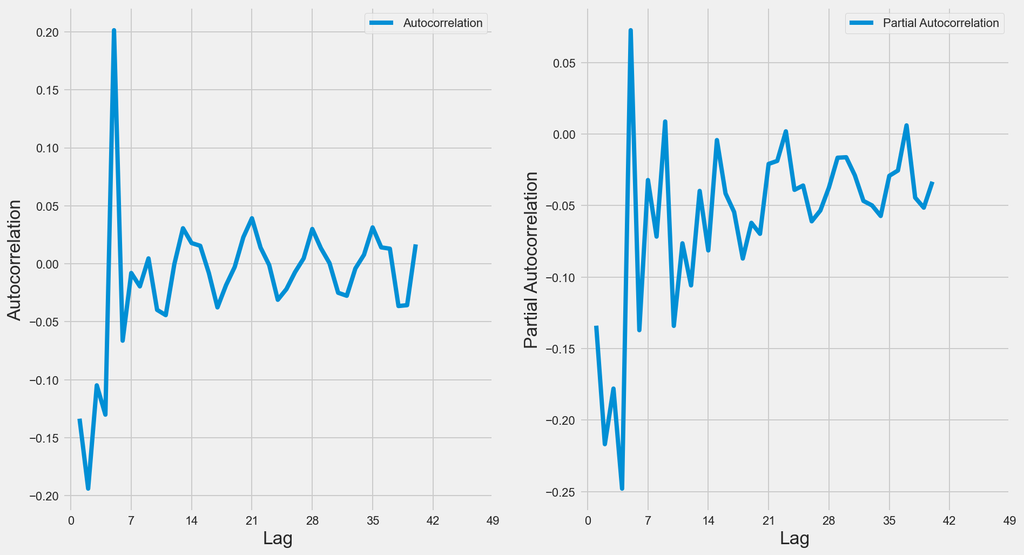

```python
def plot_acf_pacf(ts):
    from statsmodels.tsa.stattools import acf
    from statsmodels.tsa.stattools import pacf

    # data
    data = ts.to_numpy().ravel()

    # fig setup
    fig = plt.figure(1,figsize=(14,8))
    ax1 = fig.add_subplot(121)
    ax2 = fig.add_subplot(122)

    # differencing or lagging
    data_diff = [data[i] - data[i-1] for i in range(1,len(data))]

    # acf and pacf
    autocorr = acf(data_diff,fft=False)
    pac = pacf(data_diff)

    # array for plotting
    x = [x for x in range(len(pac))]

    # acf
    ax1.plot(x[1:],autocorr[1:],label='Autocorrelation')
    ax1.set_xlabel('Lag')
    ax1.set_ylabel('Autocorrelation')

    # pacf
    ax2.plot(x[1:],pac[1:],label='Partial Autocorrelation')
    ax2.set_xlabel('Lag')
    ax2.set_ylabel('Partial Autocorrelation')

    # show
    ax1.set_xticks(range(0,50,7))
    ax2.set_xticks(range(0,50,7))
    ax1.legend()
    ax2.legend()
    plt.show()

plot_acf_pacf(ts)
```

```python
# we can see strong correlations and anti-correlations weekly
```

# Seasonal Decomposition

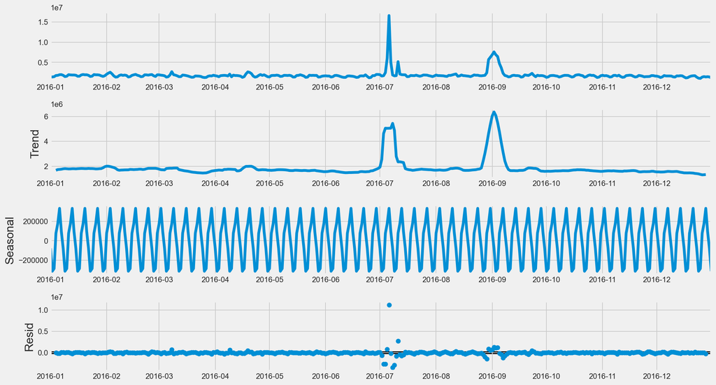

```python
import statsmodels.api as sm
import statsmodels.formula.api as smf
import statsmodels.graphics.api as smg
import statsmodels.robust as smrb # smrb.mad() etc
import patsy # y,X1 = patsy.dmatrices(formula, df, return_type='dataframe')


res = sm.tsa.seasonal_decompose(ts, model='additive')
fig = res.plot()
fig.set_figheight(8)
fig.set_figwidth(15)
```

# Trend Analysis

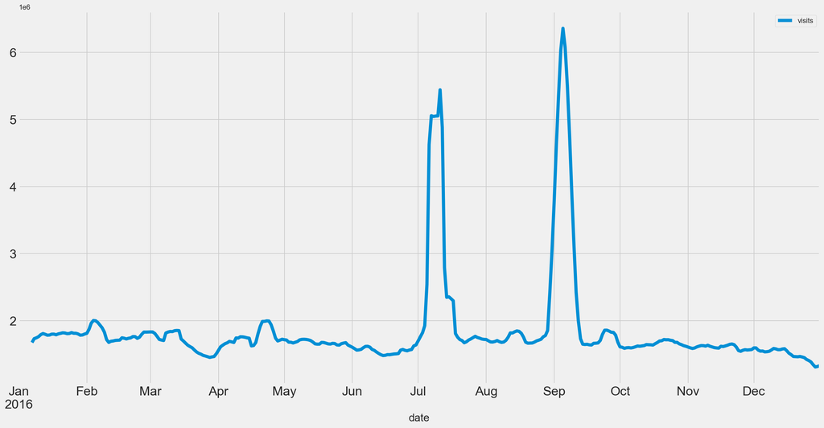

```python
ts.rolling(7).mean().plot(figsize=(20,10), linewidth=5, fontsize=20)
# we do not see trend, it is not inreasing or decreasing.
```

# Seasonability Analysis

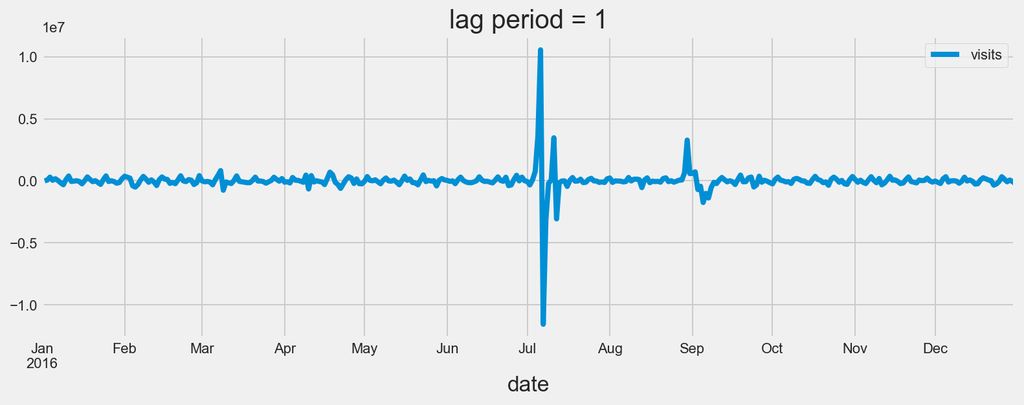

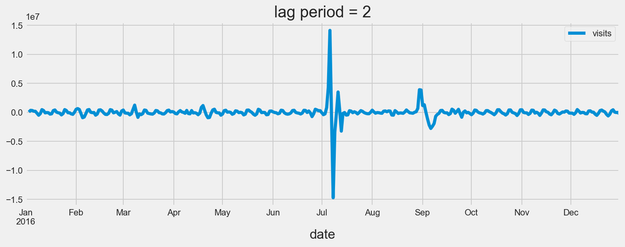

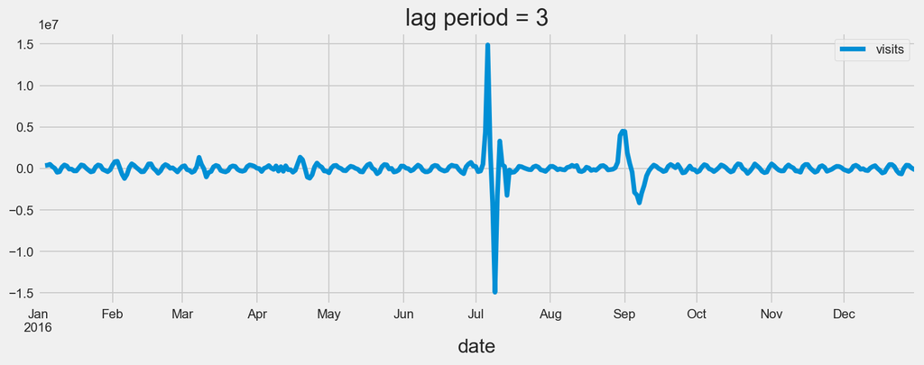

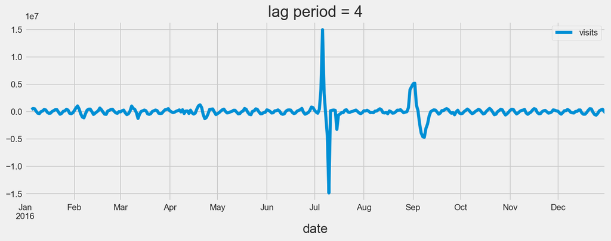

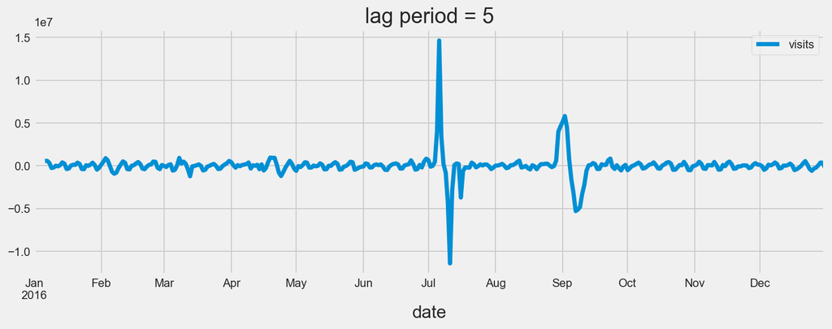

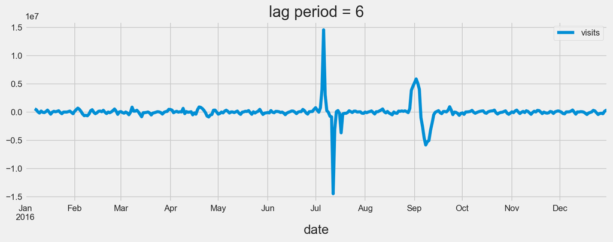

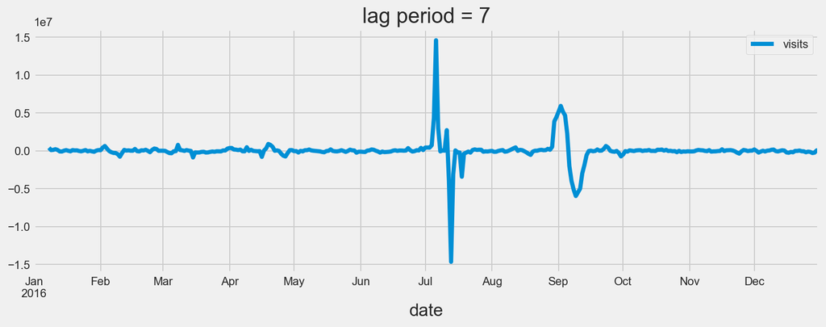

```python
for i in range(1,8):
    ts.diff(i).plot(figsize=(12,4))
    plt.title('lag period = '+ str(i))
    plt.show()
```

# Periodicity and Autocorrelation

X-axis is number of lag h.

Y-axis is Autocorrlation of timeseries to lag of itself. $$ C_{n}=\sum_{t=1}^{n-h}(y(t)-\hat{y})(y(t+n)-\hat{y}) / n $$

$$ C_{0}=\sum_{t=1}^{n}(y(t)-\hat{y})^{2} / n $$

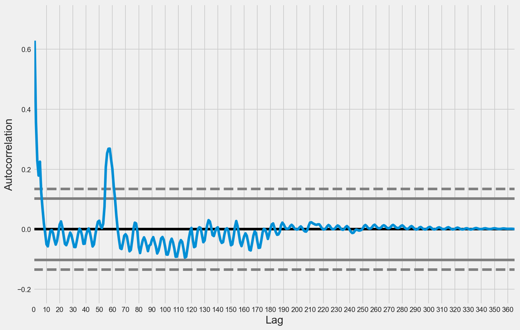

```python
plt.figure(figsize=(12,8))
pd.plotting.autocorrelation_plot(ts)
plt.ylim(-0.25,0.75)
plt.grid(True)
plt.xticks(range(0,370,10));
```

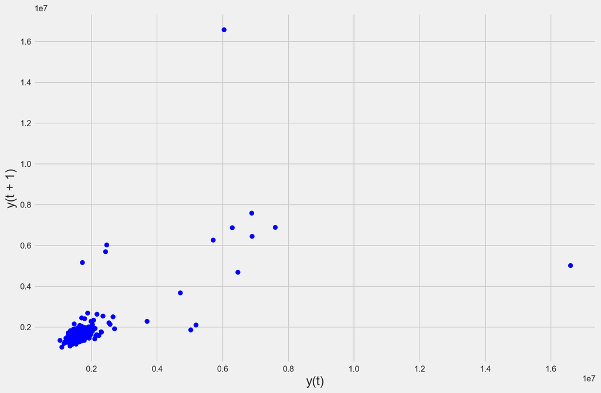

```python
plt.figure(figsize=(12,8))
pd.plotting.lag_plot(ts,c='blue')
```

```python
ts.head().append(ts.tail())
```

| date | visits |
| --- | --- |
| 2016-01-01 | 1401667.0 |
| 2016-01-02 | 1395136.0 |
| 2016-01-03 | 1455522.0 |
| 2016-01-04 | 1750373.0 |
| 2016-01-05 | 1787494.0 |
| 2016-12-27 | 1481319.0 |
| 2016-12-28 | 1399599.0 |
| 2016-12-29 | 1455447.0 |
| 2016-12-30 | 1397331.0 |
| 2016-12-31 | 1175657.0 |